# Analysis of soil carbon controls across the Pacific Northwest

Anthony Stewart

```
## 'data.frame':    481 obs. of  25 variables:
##  $ X                   : int  1 2 3 4 5 6 7 8 9 10 ...
##  $ sample_ID           : chr  "H-C-01-DNR-WET" "H-C-01-DNR-WET" "H-C-01-DNR-WET" "H-C-01-DNR-WET" ...
##  $ site                : chr  "HOH" "HOH" "HOH" "HOH" ...
##  $ depth_cm            : int  13 40 76 104 11 30 45 75 9 27 ...
##  $ helper              : chr  "H-C-01-DNR-WET|13" "H-C-01-DNR-WET|40" "H-C-01-DNR-WET|76" "H-C-01-DNR-WET|104" ...
##  $ thickness_cm        : int  13 27 36 28 11 19 15 30 9 18 ...
##  $ rock_perc           : num  0 0 5 40 0 15 40 55 0 0 ...
##  $ BD_g_cm3            : num  0.07 0.16 0.51 0.88 0.38 0.49 0.7 0.57 0.72 0.95 ...
##  $ field_texture       : chr  "P" "MP" "MM" "C" ...
##  $ field_texture_binned: chr  "O" "O" "O" "C" ...
##  $ redox               : chr  NA NA NA NA ...
##  $ carbon_perc         : num  39.56 38.31 12.14 2.37 15.65 ...
##  $ carbon_stock_g_cm2  : num  0.376 1.678 2.105 0.352 0.65 ...
##  $ NDYI                : num  0.543 0.543 0.543 0.543 0.579 ...
```

[output cut: 37 more lines]

With many potential predictors we can eliminate some by examining correlation plots

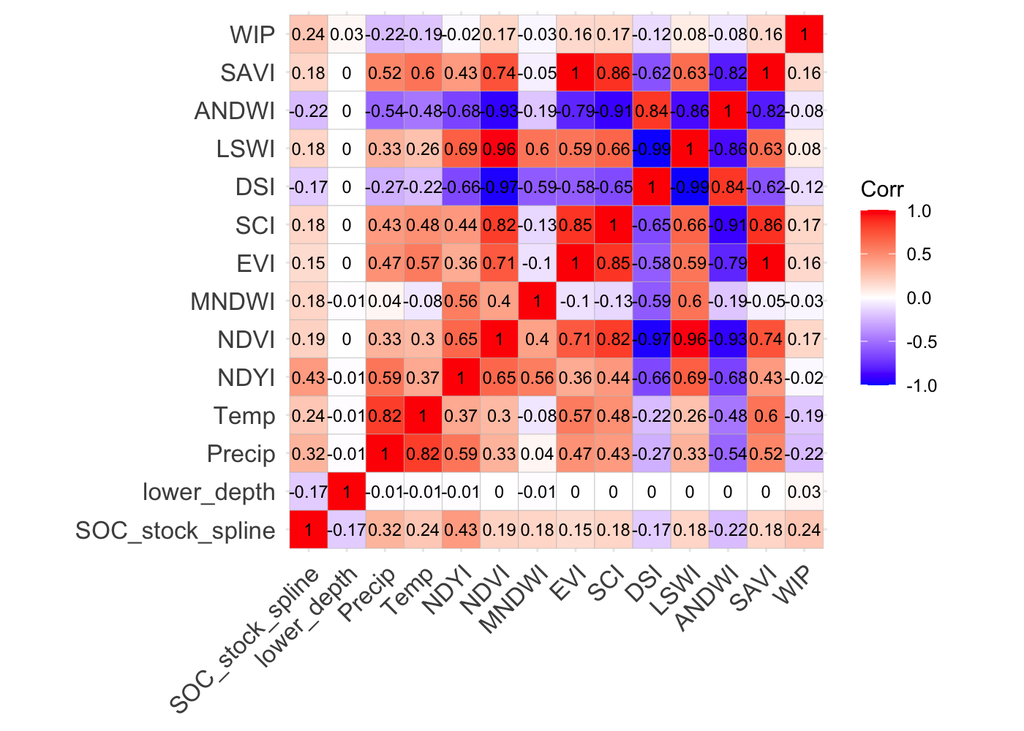

There is weak correlation between `SOC_stock_spline` and the selected covariates. Additionally there is some collinearity between predictors. The spectral predictors such as EVI (Enhanced Vegetation Index) and SCI (Soil Condition Index) are well correlated with each other and also with NDVI (Normalized Difference Vegetation Index). We can remove these based on the correlation coefficient > 0.7.

Now we can begin examining the distribution of carbon stock values in the dataset to choose the appropriate transformation. We also scale and center the numeric predictor variables.

```
## 'data.frame':    276 obs. of  25 variables:
##  $ X                : num [1:276, 1] -1.72 -1.71 -1.7 -1.69 -1.67 ...
##   ..- attr(*, "scaled:center")= num 138
##   ..- attr(*, "scaled:scale")= num 79.8
##  $ sample_ID        : chr  "CC_S26_R3" "CC_S26_R3" "CC_S26_R3" "CC_S27_R3" ...
##  $ upper_depth      : num [1:276, 1] -1.1849 0.0492 1.2833 -1.1849 0.0492 ...
##   ..- attr(*, "scaled:center")= num 28.8
##   ..- attr(*, "scaled:scale")= num 24.3
##  $ lower_depth      : int  30 60 100 30 60 100 30 60 100 30 ...
##  $ SOC_stock_spline : num  0.1636 0.0983 0.0531 0.6126 0.6936 ...
##  $ site             : chr  "COL" "COL" "COL" "COL" ...
##  $ geomorphons      : chr  "f" "f" "f" "i" ...
##  $ HLI              : num [1:276, 1] 1.264 1.264 1.264 -0.907 -0.907 ...
##   ..- attr(*, "scaled:center")= num 0.647
##   ..- attr(*, "scaled:scale")= num 0.16
##  $ Precip           : num [1:276, 1] -1.21 -1.21 -1.21 -1.18 -1.18 ...
##   ..- attr(*, "scaled:center")= num 1870
##   ..- attr(*, "scaled:scale")= num 1022
##  $ Temp             : num [1:276, 1] -1.09 -1.09 -1.09 -1.48 -1.48 ...
##   ..- attr(*, "scaled:center")= num 8.42
##   ..- attr(*, "scaled:scale")= num 1.62
##  $ WIP              : num [1:276, 1] -0.801 -0.801 -0.801 -1.08 -1.08 ...
##   ..- attr(*, "scaled:center")= num 0.443
##   ..- attr(*, "scaled:scale")= num 0.292
##  $ tree_canopy_cover: num [1:276, 1] -2.25 -2.25 -2.25 -0.264 -0.264 ...
##   ..- attr(*, "scaled:center")= num 59.3
##   ..- attr(*, "scaled:scale")= num 12.6
##  $ NDVI             : num [1:276, 1] -3.5 -3.5 -3.5 -1.1 -1.1 ...
##   ..- attr(*, "scaled:center")= num 0.832
##   ..- attr(*, "scaled:scale")= num 0.0843
##  $ MNDWI            : num [1:276, 1] -0.324 -0.324 -0.324 -1.105 -1.105 ...
##   ..- attr(*, "scaled:center")= num -0.502
##   ..- attr(*, "scaled:scale")= num 0.0475
##  $ EVI              : num [1:276, 1] -1.932 -1.932 -1.932 -0.953 -0.953 ...
##   ..- attr(*, "scaled:center")= num 0.48
##   ..- attr(*, "scaled:scale")= num 0.0972
##  $ SCI              : num [1:276, 1] -2.81 -2.81 -2.81 -0.8 -0.8 ...
##   ..- attr(*, "scaled:center")= num 0.658
##   ..- attr(*, "scaled:scale")= num 0.0526
##  $ SAVI             : num [1:276, 1] -2.17 -2.17 -2.17 -1.02 -1.02 ...
##   ..- attr(*, "scaled:center")= num 0.466
##   ..- attr(*, "scaled:scale")= num 0.0811
##  $ EMBI             : num [1:276, 1] 1.52 1.52 1.52 1.3 1.3 ...
##   ..- attr(*, "scaled:center")= num 0.00762
##   ..- attr(*, "scaled:scale")= num 0.119
##  $ DSI              : num [1:276, 1] 3.03 3.03 3.03 1.2 1.2 ...
##   ..- attr(*, "scaled:center")= num 0.432
##   ..- attr(*, "scaled:scale")= num 0.161
##  $ DSWI1            : num [1:276, 1] -1.99 -1.99 -1.99 -1.36 -1.36 ...
##   ..- attr(*, "scaled:center")= num 2.58
##   ..- attr(*, "scaled:scale")= num 0.714
##  $ NDYI             : num [1:276, 1] -2.215 -2.215 -2.215 -0.683 -0.683 ...
##   ..- attr(*, "scaled:center")= num 0.419
##   ..- attr(*, "scaled:scale")= num 0.0874
##  $ LSWI             : num [1:276, 1] -2.61 -2.61 -2.61 -1.33 -1.33 ...
##   ..- attr(*, "scaled:center")= num 0.413
##   ..- attr(*, "scaled:scale")= num 0.137
##  $ ANDWI            : num [1:276, 1] 2.92 2.92 2.92 1.08 1.08 ...
##   ..- attr(*, "scaled:center")= num -0.703
##   ..- attr(*, "scaled:scale")= num 0.0564
##  $ LITHOLOGY        : chr  "continental glacial outwash, Fraser-age" "continental glacial outwash, Fraser-age" "continental glacial outwash, Fraser-age" "continental glacial outwash, Fraser-age" ...
##  $ GEOLOGIC_AGE     : chr  "Pleistocene" "Pleistocene" "Pleistocene" "Pleistocene" ...
```

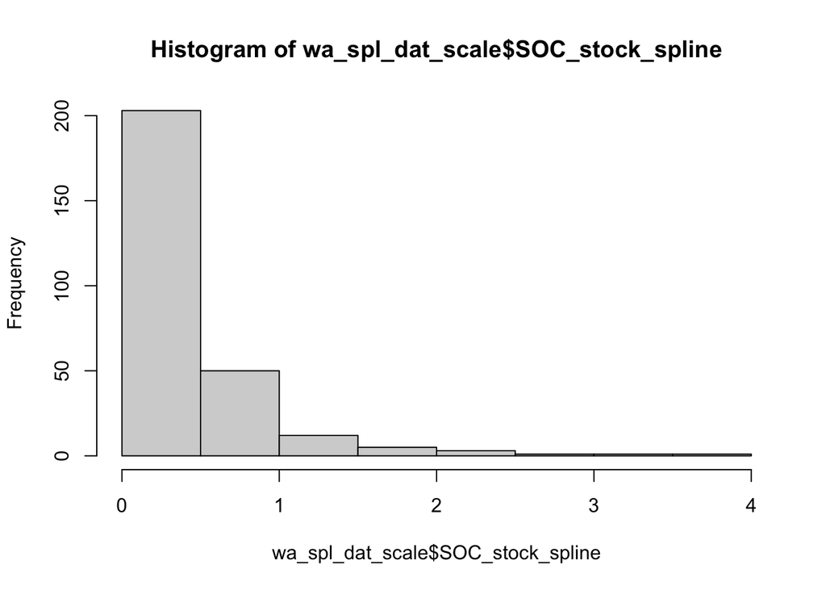

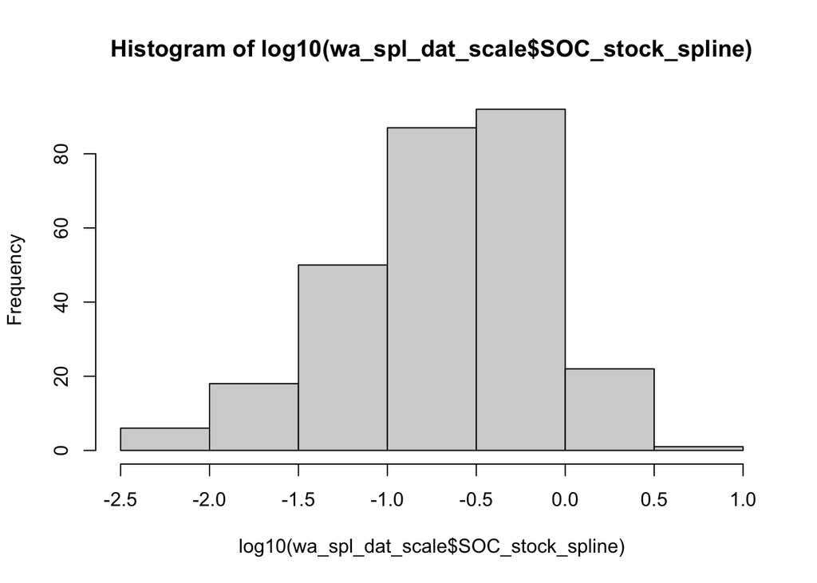

### Explicit parameter model building

Now build models using log transformed carbon stock data. We need to specify that `sample_ID` is a random effect because of the multiple samples at one location. `lower_depth` will be a random slope to adjust model based on how it is affected by depth. We could use a Generalized Linear Model or a Generalized Linear Mixed Model here too but they often fail to converge. We will model with the log-transformed soil carbon stocks in the linear mixed model

```r
# Full model with hypothesized parameters
mod1 <- lmer(log10(SOC_stock_spline) ~ WIP * Precip * Temp *
    ANDWI * NDYI + (GEOLOGIC_AGE) + lower_depth + (lower_depth ||
    sample_ID), data = wa_spl_dat_scale, REML = F)
## Warning in checkConv(attr(opt, "derivs"), opt$par, ctrl = control$checkConv, :
## Model failed to converge with max|grad| = 0.0029585 (tol = 0.002, component 1)
# No interactions
mod2 <- lmer(log10(SOC_stock_spline) ~ WIP + Precip + Temp +
    ANDWI + NDYI + (GEOLOGIC_AGE) + lower_depth + (lower_depth ||
    sample_ID), data = wa_spl_dat_scale, REML = F)
# No spectral
mod3 <- lmer(log10(SOC_stock_spline) ~ WIP * Precip * Temp +
    (GEOLOGIC_AGE) + lower_depth + (lower_depth || sample_ID),
    data = wa_spl_dat_scale, REML = F)
# No geology
mod4 <- lmer(log10(SOC_stock_spline) ~ WIP * Precip * Temp +
    ANDWI + NDYI + lower_depth + (lower_depth || sample_ID),
    data = wa_spl_dat_scale, REML = F)
# No WIP w/ interaction
mod5 <- lmer(log10(SOC_stock_spline) ~ Precip * Temp + ANDWI +
    NDYI + (GEOLOGIC_AGE) + lower_depth + (lower_depth || sample_ID),
    data = wa_spl_dat_scale, REML = F)
## Warning in checkConv(attr(opt, "derivs"), opt$par, ctrl = control$checkConv, :
## Model failed to converge with max|grad| = 1.55619 (tol = 0.002, component 1)
# No WIP w/o interaction
mod6 <- lmer(log10(SOC_stock_spline) ~ Precip + Temp + ANDWI +
    NDYI + (GEOLOGIC_AGE) + lower_depth + (lower_depth || sample_ID),
    data = wa_spl_dat_scale, REML = F)
# No climate
mod7 <- lmer(log10(SOC_stock_spline) ~ WIP + +ANDWI + NDYI +
    (GEOLOGIC_AGE) + lower_depth + (lower_depth || sample_ID),
    data = wa_spl_dat_scale, REML = F)
# No climate No spectral
mod8 <- lmer(log10(SOC_stock_spline) ~ WIP + (GEOLOGIC_AGE) +
    lower_depth + (lower_depth || sample_ID), data = wa_spl_dat_scale,
    REML = F)
## Warning in checkConv(attr(opt, "derivs"), opt$par, ctrl = control$checkConv, :
## Model failed to converge with max|grad| = 0.0035401 (tol = 0.002, component 1)
# Just WIP
mod9 <- lmer(log10(SOC_stock_spline) ~ WIP + lower_depth + (lower_depth ||
    sample_ID), data = wa_spl_dat_scale, REML = F)
# NULL
mod10 <- lmer(log10(SOC_stock_spline) ~ lower_depth + (lower_depth ||
    sample_ID), data = wa_spl_dat_scale, REML = F)
## Warning in checkConv(attr(opt, "derivs"), opt$par, ctrl = control$checkConv, :
## Model failed to converge with max|grad| = 0.431569 (tol = 0.002, component 1)
```

Pairwise comparisons between the top, largest model and the rest show if models with fewer parameters are significantly different. Considering AIC will help determine the most parsimonious model with the best fit to the data.

| Models | npar | AIC | BIC | logLik | deviance | Chisq | Df | Pr(>Chisq) | Significant |
| --- | --- | --- | --- | --- | --- | --- | --- | --- | --- |
| mod2 | 15 | 220.4259 | 274.7319 | -95.21296 | 190.4259 | NA | NA | NA |  |
| mod1 | 41 | 235.9051 | 384.3416 | -76.95256 | 153.9051 | 36.52080 | 26 | 0.0824988 |  |
| mod3 | 17 | 223.7913 | 285.3381 | -94.89564 | 189.7913 | NA | NA | NA |  |
| mod1 | 41 | 235.9051 | 384.3416 | -76.95256 | 153.9051 | 35.88615 | 24 | 0.0562988 |  |
| mod4 | 14 | 227.0389 | 277.7245 | -99.51945 | 199.0389 | NA | NA | NA |  |
| mod1 | 41 | 235.9051 | 384.3416 | -76.95256 | 153.9051 | 45.13377 | 27 | 0.0157401 | *** |
| mod5 | 15 | 229.4435 | 283.7495 | -99.72175 | 199.4435 | NA | NA | NA |  |
| mod1 | 41 | 235.9051 | 384.3416 | -76.95256 | 153.9051 | 45.53837 | 26 | 0.0102674 | *** |
| mod6 | 14 | 229.4083 | 280.0939 | -100.70415 | 201.4083 | NA | NA | NA |  |
| mod1 | 41 | 235.9051 | 384.3416 | -76.95256 | 153.9051 | 47.50318 | 27 | 0.0087196 | *** |
| mod7 | 13 | 230.4420 | 277.5072 | -102.22099 | 204.4420 | NA | NA | NA |  |
| mod1 | 41 | 235.9051 | 384.3416 | -76.95256 | 153.9051 | 50.53685 | 28 | 0.0056307 | *** |
| mod8 | 11 | 247.7352 | 287.5596 | -112.86760 | 225.7352 | NA | NA | NA |  |
| mod1 | 41 | 235.9051 | 384.3416 | -76.95256 | 153.9051 | 71.83007 | 30 | 0.0000275 | *** |
| mod9 | 6 | 245.6252 | 267.3476 | -116.81262 | 233.6252 | NA | NA | NA |  |
| mod1 | 41 | 235.9051 | 384.3416 | -76.95256 | 153.9051 | 79.72011 | 35 | 0.0000243 | *** |
| mod10 | 5 | 247.8359 | 265.9379 | -118.91797 | 237.8359 | NA | NA | NA |  |
| mod1 | 41 | 235.9051 | 384.3416 | -76.95256 | 153.9051 | 83.93081 | 36 | 0.0000107 | *** |

From the ANOVAs it looks like `model 2` & `model 3` performed just as well as `model 1`meaning we should proceed with these. `model 2` removed interactions and `model 3` removed all the spectral metrics but kept interaction. However, `model 2` has 2 less parameters than `model 3` which gives it a lower AIC when compared together.

|  | npar | AIC | BIC | logLik | deviance | Chisq | Df | Pr(>Chisq) |
| --- | --- | --- | --- | --- | --- | --- | --- | --- |
| mod2 | 15 | 220.4259 | 274.7319 | -95.21296 | 190.4259 | NA | NA | NA |
| mod3 | 17 | 223.7913 | 285.3381 | -94.89564 | 189.7913 | 0.6346545 | 2 | 0.7280925 |

To hone in on differences between variations in `model 2` we can remove some of the variables and compare AICs for a more parsimonious fit.

```r
# No ANDWI
mod2.1 <- lmer(log10(SOC_stock_spline) ~ WIP + Precip + Temp +
    NDYI + (GEOLOGIC_AGE) + lower_depth + (lower_depth || sample_ID),
    data = wa_spl_dat_scale, REML = F)
# No ANDWI, No NDYI
mod2.2 <- lmer(log10(SOC_stock_spline) ~ WIP + Precip + Temp +
    (GEOLOGIC_AGE) + lower_depth + (lower_depth || sample_ID),
    data = wa_spl_dat_scale, REML = F)
## Warning in checkConv(attr(opt, "derivs"), opt$par, ctrl = control$checkConv, :
## Model failed to converge with max|grad| = 0.0070341 (tol = 0.002, component 1)
# No NDYI
mod2.3 <- lmer(log10(SOC_stock_spline) ~ WIP + Precip + Temp +
    ANDWI + (GEOLOGIC_AGE) + lower_depth + (lower_depth || sample_ID),
    data = wa_spl_dat_scale, REML = F)
## Warning in checkConv(attr(opt, "derivs"), opt$par, ctrl = control$checkConv, :
## Model failed to converge with max|grad| = 0.00988007 (tol = 0.002, component 1)
# No Geology
mod2.4 <- lmer(log10(SOC_stock_spline) ~ WIP + Precip + Temp +
    ANDWI + NDYI + lower_depth + (lower_depth || sample_ID),
    data = wa_spl_dat_scale, REML = F)
# No NDYI or Geology
mod2.5 <- lmer(log10(SOC_stock_spline) ~ WIP + Precip + Temp +
    ANDWI + lower_depth + (lower_depth || sample_ID), data = wa_spl_dat_scale,
    REML = F)
## Warning in checkConv(attr(opt, "derivs"), opt$par, ctrl = control$checkConv, :
## Model failed to converge with max|grad| = 0.0427663 (tol = 0.002, component 1)
# No ANDWI or Geology
mod2.6 <- lmer(log10(SOC_stock_spline) ~ WIP + Precip + Temp +
    NDYI + lower_depth + (lower_depth || sample_ID), data = wa_spl_dat_scale,
    REML = F)
# No spectral or Geology
mod2.7 <- lmer(log10(SOC_stock_spline) ~ WIP + Precip + Temp +
    lower_depth + (lower_depth || sample_ID), data = wa_spl_dat_scale,
    REML = F)
```

| Models | npar | AIC | BIC | logLik | deviance | Chisq | Df | Pr(>Chisq) | Significant |
| --- | --- | --- | --- | --- | --- | --- | --- | --- | --- |
| mod2.1 | 14 | 218.8356 | 269.5212 | -95.41779 | 190.8356 | NA | NA | NA |  |
| mod2 | 15 | 220.4259 | 274.7319 | -95.21296 | 190.4259 | 0.409648 | 1 | 0.5221482 |  |
| mod2.2 | 13 | 219.4581 | 266.5234 | -96.72907 | 193.4581 | NA | NA | NA |  |
| mod2 | 15 | 220.4259 | 274.7319 | -95.21296 | 190.4259 | 3.032215 | 2 | 0.2195649 |  |
| mod2.3 | 14 | 221.3227 | 272.0083 | -96.66134 | 193.3227 | NA | NA | NA |  |
| mod2 | 15 | 220.4259 | 274.7319 | -95.21296 | 190.4259 | 2.896744 | 1 | 0.0887587 |  |
| mod2.4 | 10 | 221.3976 | 257.6016 | -100.69879 | 201.3976 | NA | NA | NA |  |
| mod2 | 15 | 220.4259 | 274.7319 | -95.21296 | 190.4259 | 10.971659 | 5 | 0.0519448 |  |
| mod2.5 | 9 | 227.2392 | 259.8228 | -104.61960 | 209.2392 | NA | NA | NA |  |
| mod2 | 15 | 220.4259 | 274.7319 | -95.21296 | 190.4259 | 18.813263 | 6 | 0.0044909 | *** |
| mod2.6 | 9 | 220.0621 | 252.6457 | -101.03105 | 202.0621 | NA | NA | NA |  |
| mod2 | 15 | 220.4259 | 274.7319 | -95.21296 | 190.4259 | 11.636166 | 6 | 0.0705954 |  |
| mod2.7 | 8 | 226.0611 | 255.0243 | -105.03055 | 210.0611 | NA | NA | NA |  |
| mod2 | 15 | 220.4259 | 274.7319 | -95.21296 | 190.4259 | 19.635164 | 7 | 0.0064141 | *** |

`Model 2.1` and `2.2` are the lowest AIC and not significantly different from the fit in `Model 2`. Because `Model 2.2` failed to converge, we will move forward with `Model 2.1`.

Now we can look at the table of all models and compare AICs. We find that Model 2.1 has the lowest AIC followed by `Model 2.2` which failed to converge

| AIC | formula | name | delta |
| --- | --- | --- | --- |
| 235.91 | WIP * Precip * Temp * ANDWI * NDYI + (GEOLOGIC_AGE) + lower_depth + ((1 \| sample_ID) + (0 + lower_depth \| sample_ID)) | mod1 | 17.07 |
| 220.43 | WIP + Precip + Temp + ANDWI + NDYI + (GEOLOGIC_AGE) + lower_depth + ((1 \| sample_ID) + (0 + lower_depth \| sample_ID)) | mod2 | 1.59 |
| 223.79 | WIP * Precip * Temp + (GEOLOGIC_AGE) + lower_depth + ((1 \| sample_ID) + (0 + lower_depth \| sample_ID)) | mod3 | 4.95 |
| 227.04 | WIP * Precip * Temp + ANDWI + NDYI + lower_depth + ((1 \| sample_ID) + (0 + lower_depth \| sample_ID)) | mod4 | 8.20 |
| 229.44 | Precip * Temp + ANDWI + NDYI + (GEOLOGIC_AGE) + lower_depth + ((1 \| sample_ID) + (0 + lower_depth \| sample_ID)) | mod5 | 10.60 |
| 229.41 | Precip + Temp + ANDWI + NDYI + (GEOLOGIC_AGE) + lower_depth + ((1 \| sample_ID) + (0 + lower_depth \| sample_ID)) | mod6 | 10.57 |
| 230.44 | WIP + +ANDWI + NDYI + (GEOLOGIC_AGE) + lower_depth + ((1 \| sample_ID) + (0 + lower_depth \| sample_ID)) | mod7 | 11.60 |
| 247.74 | WIP + (GEOLOGIC_AGE) + lower_depth + ((1 \| sample_ID) + (0 + lower_depth \| sample_ID)) | mod8 | 28.90 |
| 245.63 | WIP + lower_depth + ((1 \| sample_ID) + (0 + lower_depth \| sample_ID)) | mod9 | 26.79 |
| 218.84 | WIP + Precip + Temp + NDYI + (GEOLOGIC_AGE) + lower_depth + ((1 \| sample_ID) + (0 + lower_depth \| sample_ID)) | mod2.1 | 0.00 |
| 219.46 | WIP + Precip + Temp + (GEOLOGIC_AGE) + lower_depth + ((1 \| sample_ID) + (0 + lower_depth \| sample_ID)) | mod2.2 | 0.62 |
| 221.32 | WIP + Precip + Temp + ANDWI + (GEOLOGIC_AGE) + lower_depth + ((1 \| sample_ID) + (0 + lower_depth \| sample_ID)) | mod2.3 | 2.48 |
| 221.4 | WIP + Precip + Temp + ANDWI + NDYI + lower_depth + ((1 \| sample_ID) + (0 + lower_depth \| sample_ID)) | mod2.4 | 2.56 |
| 227.24 | WIP + Precip + Temp + ANDWI + lower_depth + ((1 \| sample_ID) + (0 + lower_depth \| sample_ID)) | mod2.5 | 8.40 |
| 220.06 | WIP + Precip + Temp + NDYI + lower_depth + ((1 \| sample_ID) + (0 + lower_depth \| sample_ID)) | mod2.6 | 1.22 |
| 226.06 | WIP + Precip + Temp + lower_depth + ((1 \| sample_ID) + (0 + lower_depth \| sample_ID)) | mod2.7 | 7.22 |

The model $R^2$ for `mod2.1` is 0.892

Confidence intervals calculated with bootstrapping show that `WIP` and `Precip` are the most significant contributors to SOC stock. the overlapping confidence intervals do not show much separation between `WIP` and `Precip` but there is more variation in the `Precip` confidence interval.

|  | Model 2.1 |  |  |
| --- | --- | --- | --- |
| Predictors | Estimates | CI | p |
| (Intercept) | -0.24 | -0.63 – 0.11 | 0.192 |
| WIP | 0.12 | 0.05 – 0.19 | **<0.001** |
| Precip | 0.18 | 0.03 – 0.32 | **0.020** |
| Temp | -0.00 | -0.12 – 0.12 | 0.992 |
| NDYI | 0.07 | -0.02 – 0.16 | 0.116 |
| GEOLOGIC AGE [Miocene-Eocene] | -0.44 | -0.90 – 0.09 | 0.108 |
| GEOLOGIC AGE [Oligocene-Eocene] | 0.09 | -0.29 – 0.52 | 0.654 |
| GEOLOGIC AGE [Pleistocene] | 0.04 | -0.33 – 0.46 | 0.844 |
| GEOLOGIC AGE [pre-Tertiary] | -0.05 | -0.56 – 0.48 | 0.846 |
| GEOLOGIC AGE [Quaternary] | -0.28 | -0.70 – 0.20 | 0.280 |
| lower depth | -0.01 | -0.01 – -0.01 | **<0.001** |
| Random Effects |  |  |  |
| σ<sup>2</sup> | 0.05 |  |  |
| τ<sub>00</sub> <sub>sample_ID</sub> | 0.04 |  |  |
| τ<sub>11</sub> <sub>sample_ID.lower_depth</sub> | 0.00 |  |  |
| ρ<sub>01</sub> |  |  |  |
| ρ<sub>01</sub> |  |  |  |
| ICC | 0.40 |  |  |
| N <sub>sample_ID</sub> | 96 |  |  |
| Observations | 276 |  |  |
| Marginal R<sup>2</sup> / Conditional R<sup>2</sup> | 0.554 / 0.731 |  |  |

Looking at some partial dependence plots we can see some relationships between the predicted values and `WIP` and `Precip`. The pattern in `Precip` shows the differences between the two study areas. with wetter areas having a higher range of `SOC stock`

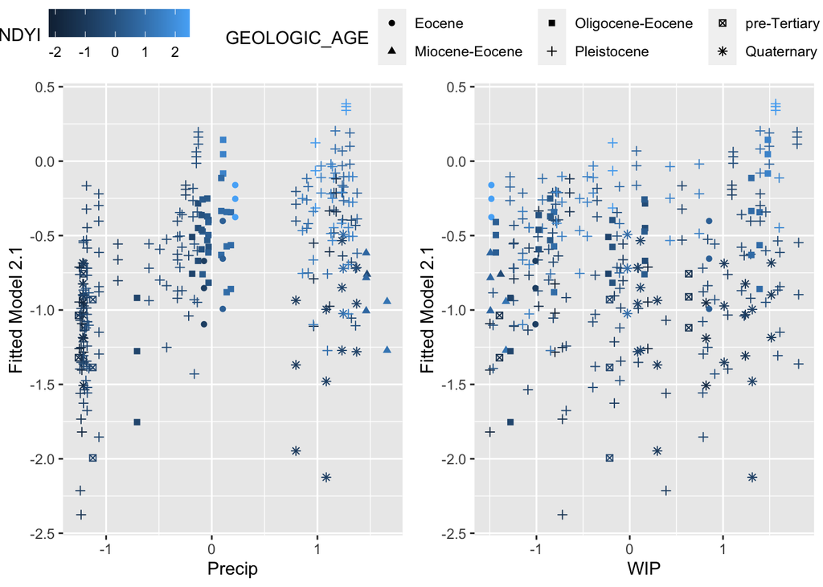

|  | Wetlands (WIP > 0.50 |  |  | Uplands (WIP < 0.50) |  |  |
| --- | --- | --- | --- | --- | --- | --- |
| Predictors | Estimates | CI | p | Estimates | CI | p |
| (Intercept) | -0.34 | -1.02 – 0.34 | 0.327 | -0.12 | -0.51 – 0.26 | 0.533 |
| WIP | 0.06 | -0.06 – 0.18 | 0.338 | 0.11 | 0.03 – 0.18 | **0.008** |
| Precip | -0.06 | -0.25 – 0.13 | 0.511 | 0.27 | 0.17 – 0.36 | **<0.001** |
| NDYI | 0.29 | 0.05 – 0.52 | **0.018** | 0.04 | -0.05 – 0.12 | 0.411 |
| GEOLOGIC AGE [Oligocene-Eocene] | -0.02 | -0.81 – 0.77 | 0.965 | -0.03 | -0.45 – 0.39 | 0.897 |
| GEOLOGIC AGE [Pleistocene] | 0.22 | -0.47 – 0.90 | 0.527 | -0.13 | -0.52 – 0.26 | 0.508 |
| GEOLOGIC AGE [pre-Tertiary] | -0.05 | -1.02 – 0.92 | 0.917 | 0.00 | -0.54 – 0.54 | 0.998 |
| GEOLOGIC AGE [Quaternary] | 0.17 | -0.61 – 0.95 | 0.672 | -0.70 | -1.25 – -0.15 | **0.013** |
| lower depth | -0.01 | -0.01 – -0.01 | **<0.001** | -0.01 | -0.01 – -0.01 | **<0.001** |
| GEOLOGIC AGE [Miocene-Eocene] |  |  |  | -0.65 | -1.15 – -0.15 | **0.011** |
| Random Effects |  |  |  |  |  |  |
| σ<sup>2</sup> | 0.07 |  |  | 0.04 |  |  |
| τ<sub>00</sub> | 0.03 <sub>sample_ID</sub> |  |  | 0.02 <sub>sample_ID</sub> |  |  |
| τ<sub>11</sub> | 0.00 <sub>sample_ID.lower_depth</sub> |  |  | 0.00 <sub>sample_ID.lower_depth</sub> |  |  |
| ρ<sub>01</sub> |  |  |  |  |  |  |
| ρ<sub>01</sub> |  |  |  |  |  |  |
| ICC | 0.32 |  |  | 0.30 |  |  |
| N | 35 <sub>sample_ID</sub> |  |  | 61 <sub>sample_ID</sub> |  |  |
| Observations | 103 |  |  | 173 |  |  |
| Marginal R<sup>2</sup> / Conditional R<sup>2</sup> | 0.569 / 0.706 |  |  | 0.647 / 0.755 |  |  |

| estimate | p.value | statistic | n | gp | Method |
| --- | --- | --- | --- | --- | --- |
| 0.2931635 | 0.002786947 | 3.066364 | 103 | 1 | pearson |

| estimate | p.value | statistic | n | gp | Method |
| --- | --- | --- | --- | --- | --- |
| 0.1055127 | 0.168344 | 1.38344 | 173 | 1 | pearson |

| estimate | p.value | statistic | n | gp | Method |
| --- | --- | --- | --- | --- | --- |
| 0.4137655 | 1.541356e-05 | 4.544958 | 103 | 1 | pearson |

| estimate | p.value | statistic | n | gp | Method |
| --- | --- | --- | --- | --- | --- |
| 0.4217667 | 8.302213e-09 | 6.065004 | 173 | 1 | pearson |

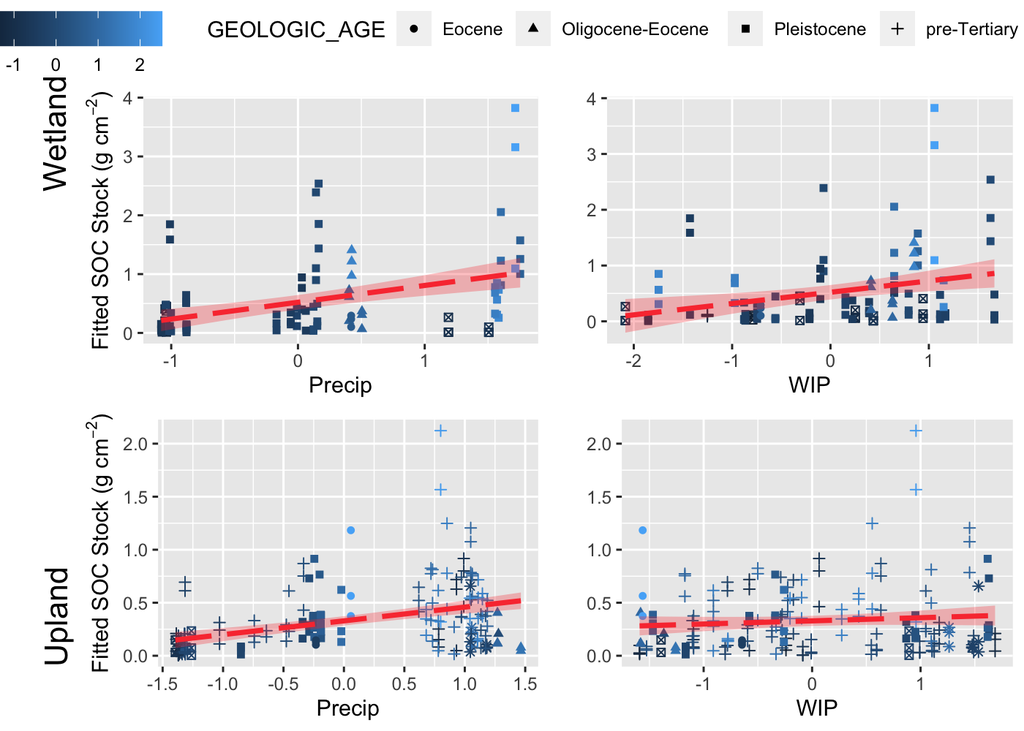

### Dredging for model selection

With the explicit hypothesized approach, we can only evaluate so many models. However, there may be interactions between variables that might be more powerful controls and could give insight into relationships between controls.

```r
gmod1 <- lmer(log10(SOC_stock_spline) ~ WIP * Temp * Precip *
    NDYI + GEOLOGIC_AGE + lower_depth + (lower_depth || sample_ID),
    data = wa_spl_dat_scale, REML = F, na.action = "na.fail")
dredge1 <- dredge(gmod1, beta = "sd")
```

|  | Dredge Model |  |  |
| --- | --- | --- | --- |
| Predictors | Estimates | CI | p |
| (Intercept) | -0.16 | -0.30 – -0.02 | **0.014** |
| lower depth | -0.01 | -0.01 – -0.01 | **<0.001** |
| NDYI | 0.44 | 0.24 – 0.64 | **<0.001** |
| Precip | -0.07 | -0.27 – 0.12 | 0.428 |
| Temp | 0.21 | 0.02 – 0.39 | **0.028** |
| WIP | 0.06 | -0.01 – 0.13 | 0.074 |
| NDYI × Precip | -0.20 | -0.33 – -0.06 | **0.002** |
| NDYI × Temp | 0.25 | 0.08 – 0.42 | **0.006** |
| NDYI × WIP | 0.09 | 0.01 – 0.18 | **0.038** |
| Precip × Temp | -0.11 | -0.26 – 0.03 | 0.104 |
| Precip × WIP | -0.14 | -0.27 – 0.00 | 0.064 |
| Temp × WIP | 0.06 | -0.07 – 0.16 | 0.326 |
| (NDYI × Precip) × Temp | -0.29 | -0.47 – -0.11 | **0.002** |
| (NDYI × Temp) × WIP | 0.08 | 0.01 – 0.15 | **0.032** |
| Random Effects |  |  |  |
| σ<sup>2</sup> | 0.05 |  |  |
| τ<sub>00</sub> <sub>sample_ID</sub> | 0.02 |  |  |
| τ<sub>11</sub> <sub>sample_ID.lower_depth</sub> | 0.00 |  |  |
| ρ<sub>01</sub> |  |  |  |
| ρ<sub>01</sub> |  |  |  |
| ICC | 0.32 |  |  |
| N <sub>sample_ID</sub> | 96 |  |  |
| Observations | 276 |  |  |
| Marginal R<sup>2</sup> / Conditional R<sup>2</sup> | 0.611 / 0.735 |  |  |

| AIC | formula | name | delta |
| --- | --- | --- | --- |
| 214.54 | lower_depth + NDYI + Precip + Temp + WIP + (1 \| sample_ID) + (0 + lower_depth \| sample_ID) + NDYI:Precip + NDYI:Temp + NDYI:WIP + Precip:Temp + Precip:WIP + Temp:WIP + NDYI:Precip:Temp + NDYI:Temp:W… | dmod1 | 0.00 |
| 216.84 | GEOLOGIC_AGE + lower_depth + NDYI + Precip + WIP + (1 \| sample_ID) + (0 + lower_depth \| sample_ID) | dmod2 | 2.30 |
| 216.22 | lower_depth + NDYI + Precip + Temp + WIP + (1 \| sample_ID) + (0 + lower_depth \| sample_ID) + NDYI:Precip + NDYI:Temp + NDYI:WIP + Precip:Temp + Precip:WIP + NDYI:Precip:Temp + NDYI:Precip:WIP | dmod3 | 1.68 |

By using `dredge` we find that there are a few candidate models that fit the data well.

The difference between the model AICs is lower than a common threshold of 2 but there is a difference between the top model and others. This model contains multiple interactions including `NDYI:Precip`, `NDYI:Temp`, `NDYI:WIP` `Precip:Temp`, `Precip:WIP`, `Temp:WIP`,`NDYI:Precip:Temp`

We can visualize some of these interactions with interaction plots against SOC stock. It looks like there is strong interaction and separation with the `NDYI` parameter and `WIP`

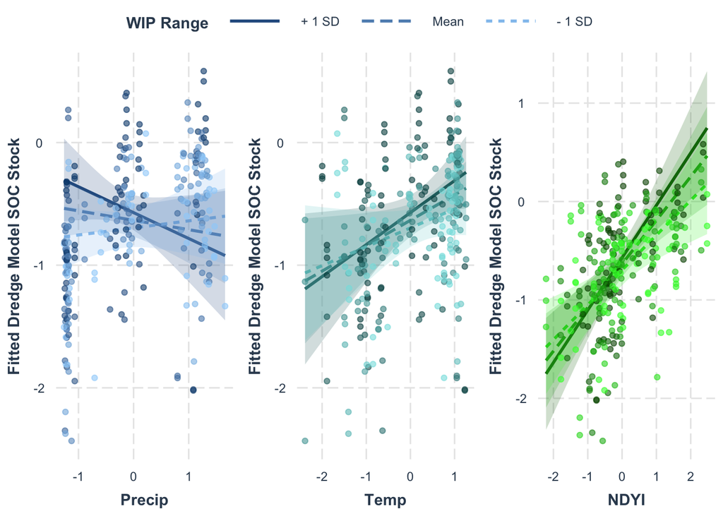

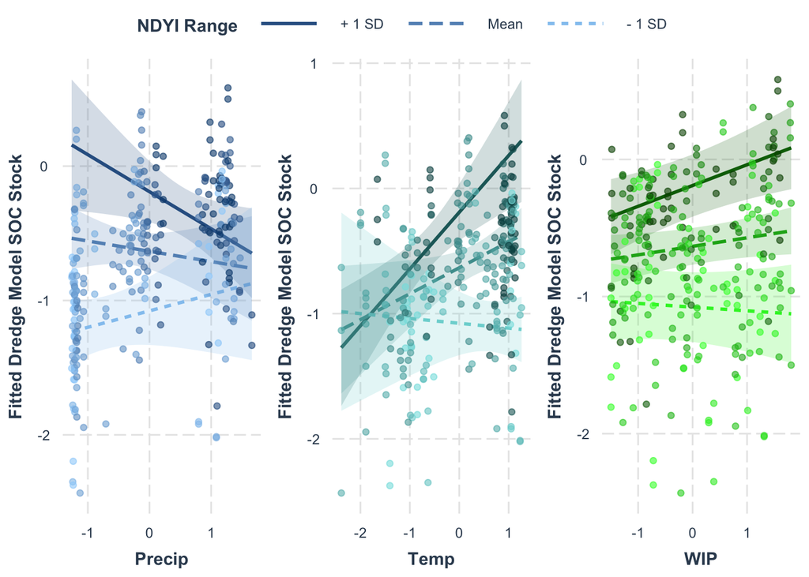

We can look at the bootstrapped confidence intervals to examine the significance of the predictors between the two models. Interestingly the `WIP` parameter alone is not significant. And there is high effect sizes for `NDYI`, `NDYI:Temp`, and `(NDYI × Precip) × Temp`

|  | Dredge Model |  |  |
| --- | --- | --- | --- |
| Predictors | Estimates | CI | p |
| (Intercept) | -0.16 | -0.30 – -0.02 | **0.014** |
| lower depth | -0.01 | -0.01 – -0.01 | **<0.001** |
| NDYI | 0.44 | 0.24 – 0.64 | **<0.001** |
| Precip | -0.07 | -0.27 – 0.12 | 0.428 |
| Temp | 0.21 | 0.02 – 0.39 | **0.028** |
| WIP | 0.06 | -0.01 – 0.13 | 0.074 |
| NDYI × Precip | -0.20 | -0.33 – -0.06 | **0.002** |
| NDYI × Temp | 0.25 | 0.08 – 0.42 | **0.006** |
| NDYI × WIP | 0.09 | 0.01 – 0.18 | **0.038** |
| Precip × Temp | -0.11 | -0.26 – 0.03 | 0.104 |
| Precip × WIP | -0.14 | -0.27 – 0.00 | 0.064 |
| Temp × WIP | 0.06 | -0.07 – 0.16 | 0.326 |
| (NDYI × Precip) × Temp | -0.29 | -0.47 – -0.11 | **0.002** |
| (NDYI × Temp) × WIP | 0.08 | 0.01 – 0.15 | **0.032** |
| Random Effects |  |  |  |
| σ<sup>2</sup> | 0.05 |  |  |
| τ<sub>00</sub> <sub>sample_ID</sub> | 0.02 |  |  |
| τ<sub>11</sub> <sub>sample_ID.lower_depth</sub> | 0.00 |  |  |
| ρ<sub>01</sub> |  |  |  |
| ρ<sub>01</sub> |  |  |  |
| ICC | 0.32 |  |  |
| N <sub>sample_ID</sub> | 96 |  |  |
| Observations | 276 |  |  |
| Marginal R<sup>2</sup> / Conditional R<sup>2</sup> | 0.611 / 0.735 |  |  |

The R$^{2}$ of the Dredge Model is R$^{2}$ = 0.897

[output not shown]

[output cut: 29 more lines]

[output not shown]

|  | Wetlands (WIP > 0.50 |  |  | Uplands (WIP < 0.50) |  |  |
| --- | --- | --- | --- | --- | --- | --- |
| Predictors | Estimates | CI | p | Estimates | CI | p |
| (Intercept) | -0.16 | -0.31 – -0.02 | **0.026** | -0.09 | -0.47 – 0.29 | 0.638 |
| lower depth | -0.01 | -0.01 – -0.01 | **<0.001** | -0.01 | -0.01 – -0.01 | **<0.001** |
| NDYI | 0.24 | 0.12 – 0.35 | **<0.001** |  |  |  |
| WIP | 0.08 | -0.04 – 0.20 | 0.213 | 0.11 | 0.03 – 0.19 | **0.006** |
| GEOLOGIC AGE [Miocene-Eocene] |  |  |  | -0.69 | -1.18 – -0.20 | **0.006** |
| GEOLOGIC AGE [Oligocene-Eocene] |  |  |  | -0.05 | -0.47 – 0.36 | 0.803 |
| GEOLOGIC AGE [Pleistocene] |  |  |  | -0.16 | -0.55 – 0.22 | 0.405 |
| GEOLOGIC AGE [pre-Tertiary] |  |  |  | -0.03 | -0.56 – 0.50 | 0.913 |
| GEOLOGIC AGE [Quaternary] |  |  |  | -0.76 | -1.29 – -0.23 | **0.005** |
| Precip |  |  |  | 0.29 | 0.21 – 0.36 | **<0.001** |
| Random Effects |  |  |  |  |  |  |
| σ<sup>2</sup> | 0.07 |  |  | 0.04 |  |  |
| τ<sub>00</sub> | 0.04 <sub>sample_ID</sub> |  |  | 0.02 <sub>sample_ID</sub> |  |  |
| τ<sub>11</sub> | 0.00 <sub>sample_ID.lower_depth</sub> |  |  | 0.00 <sub>sample_ID.lower_depth</sub> |  |  |
| ρ<sub>01</sub> |  |  |  |  |  |  |
| ρ<sub>01</sub> |  |  |  |  |  |  |
| ICC | 0.37 |  |  | 0.31 |  |  |
| N | 35 <sub>sample_ID</sub> |  |  | 61 <sub>sample_ID</sub> |  |  |
| Observations | 103 |  |  | 173 |  |  |
| Marginal R<sup>2</sup> / Conditional R<sup>2</sup> | 0.534 / 0.705 |  |  | 0.644 / 0.755 |  |  |

### Random Forest Machine Learning

Using Random Forest can see if a more flexible, machine learning model can capture any non-linear relationships or interaction relationships between parameters.

`lower_depth` is included as a predictor here in the data setup

We then use the `tuneRF` to choose the appropriate `mtry` number

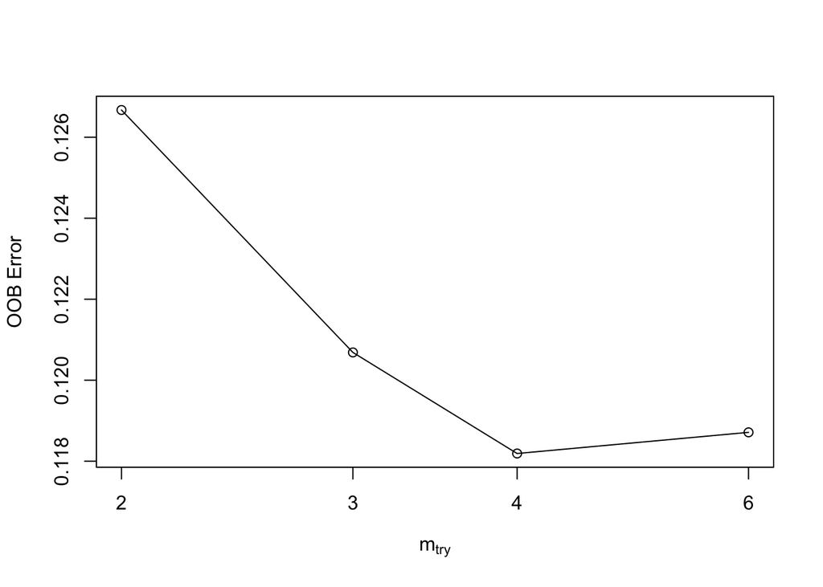

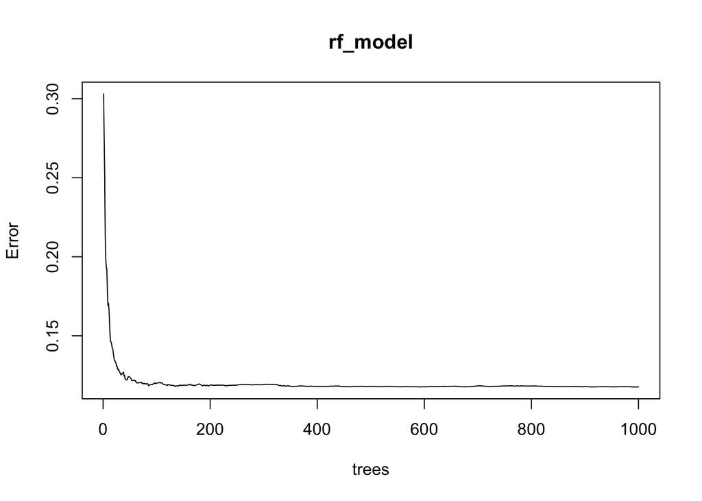

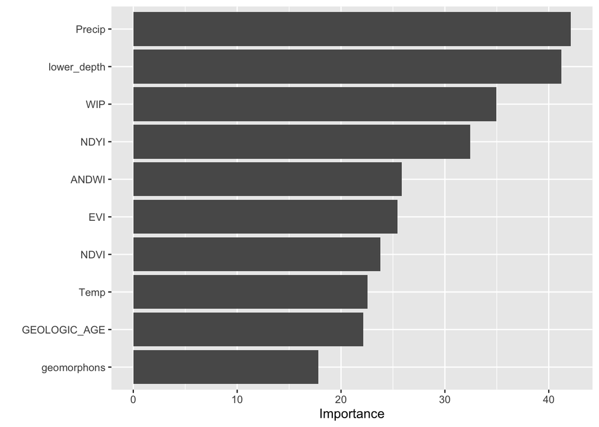

```r
rf_model <- randomForest((SOC_stock_spline) ~ ., ntree = 1000,
    mtry = 4, importance = TRUE, data = full)
plot(rf_model)

rf.full <- predict(rf_model, newdata = full)
vip::vip(rf_model)
```

61.63% of the out of bag (OOB) variation is explained. Looks like`Precip`, `lower_depth`, `WIP`, and `NDYI` are the big drivers.

| error.variable | value |
| --- | --- |
| MAE | 0.1306526 |
| MAE^2 | 0.0170701 |
| RMSE | 0.1768086 |
| RMSE non-log | 1.1934027 |
| Stdev of non-log SOC stock | 0.4999442 |
| R^2 on full dataset | 0.9230161 |

Looking at partial dependency plots we can see how `Precip` and `NDYI` have higher influence on separating variation in model predictions. `WIP` less so but seems to play a role on the higher end.

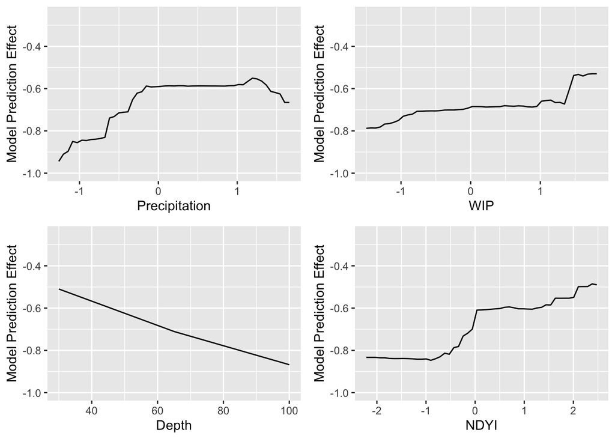

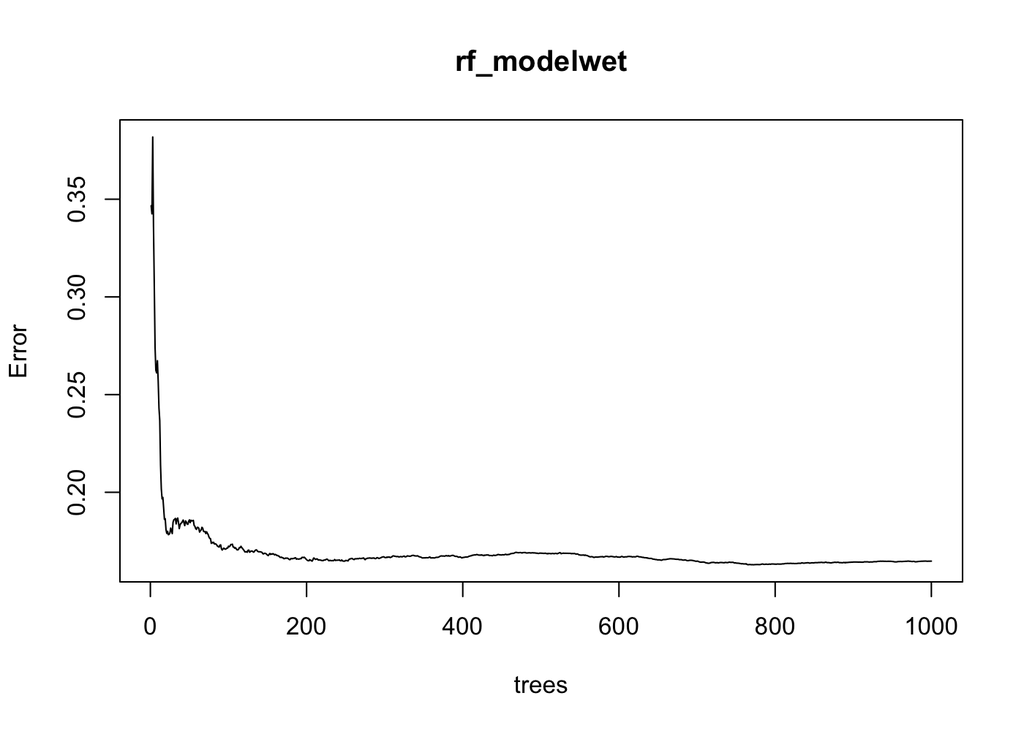

```r
fullwet <- wa_spl_dat_scale_wet[, c("SOC_stock_spline", "WIP",
    "GEOLOGIC_AGE", "Temp", "Precip", "lower_depth", "NDVI",
    "ANDWI", "EVI", "NDYI", "geomorphons")]
fullwet$GEOLOGIC_AGE <- as.character(fullwet$GEOLOGIC_AGE)
fullwet$SOC_stock_spline <- log10(fullwet$SOC_stock_spline)

fullupl <- wa_spl_dat_scale_upl[, c("SOC_stock_spline", "WIP",
    "GEOLOGIC_AGE", "Temp", "Precip", "lower_depth", "NDVI",
    "ANDWI", "EVI", "NDYI", "geomorphons")]
fullupl$GEOLOGIC_AGE <- as.character(fullupl$GEOLOGIC_AGE)
fullupl$SOC_stock_spline <- log10(fullupl$SOC_stock_spline)

rf_modelwet <- randomForest((SOC_stock_spline) ~ ., ntree = 1000,
    mtry = 4, importance = TRUE, data = fullwet)
plot(rf_modelwet)

rf.fullwet <- predict(rf_modelwet, newdata = fullwet)
wetvip <- vip::vip(rf_modelwet)
```

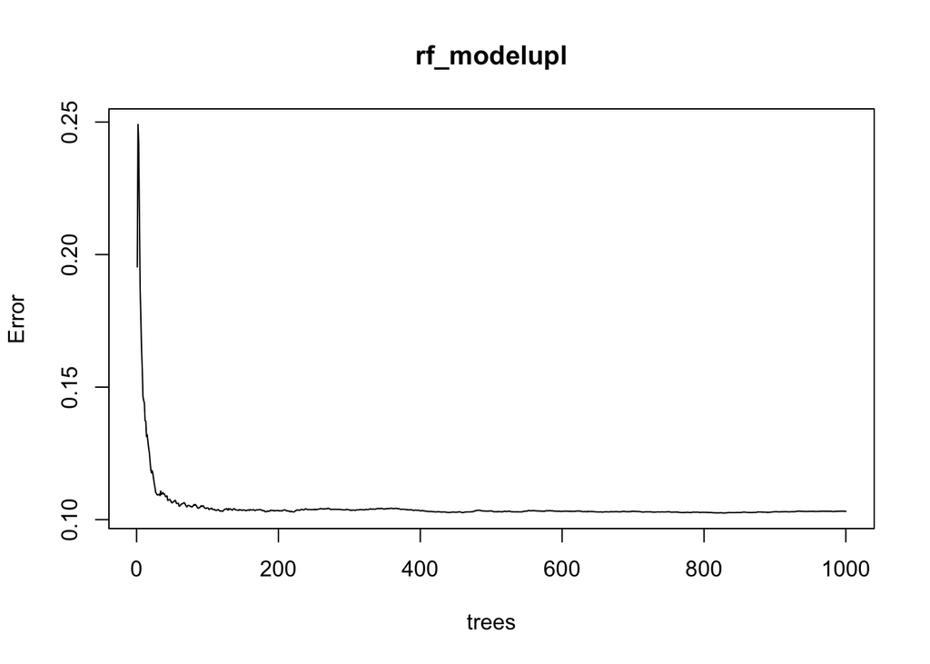

```r
rf_modelupl <- randomForest((SOC_stock_spline) ~ ., ntree = 1000,
    mtry = 4, importance = TRUE, data = fullupl)
plot(rf_modelupl)

rf.fullupl <- predict(rf_modelupl, newdata = fullupl)
uplvip <- vip::vip(rf_modelupl)
```

```r
vipwetupl <- ggarrange(wetvip, uplvip, ncol = 2, labels = c("Wetland",
    "Upland"))

ggplot2::ggsave(plot = vipwetupl, filename = paste0("/Users/Anthony/OneDrive - UW/University of Washington/Presentations/Conferences/AGU2023/ExploringControls/Figures and Tables/vipwetupl.jpeg"),
    width = 9, height = 7.5, units = "in", dpi = 500)
```

```r
library(ppcor)

pcor.test(wa_spl_dat_scale$WIP, wa_spl_dat_scale$SOC_stock_spline,
    wa_spl_dat_scale$lower_depth)
```

| estimate | p.value | statistic | n | gp | Method |
| --- | --- | --- | --- | --- | --- |
| 0.2515628 | 2.434707e-05 | 4.29461 | 276 | 1 | pearson |

```r
pcor.test(wa_spl_dat_scale$Precip, wa_spl_dat_scale$SOC_stock_spline,
    wa_spl_dat_scale$lower_depth)
```

| estimate | p.value | statistic | n | gp | Method |
| --- | --- | --- | --- | --- | --- |
| 0.320234 | 5.636864e-08 | 5.585262 | 276 | 1 | pearson |

```r
pcor.test(wa_spl_dat_scale$Temp, wa_spl_dat_scale$SOC_stock_spline,
    wa_spl_dat_scale$lower_depth)
```

| estimate | p.value | statistic | n | gp | Method |
| --- | --- | --- | --- | --- | --- |
| 0.2459375 | 3.734149e-05 | 4.192319 | 276 | 1 | pearson |

```r
pcor.test(wa_spl_dat_scale$EVI, wa_spl_dat_scale$SOC_stock_spline,
    wa_spl_dat_scale$lower_depth)
```

| estimate | p.value | statistic | n | gp | Method |
| --- | --- | --- | --- | --- | --- |
| 0.148581 | 0.01364713 | 2.482517 | 276 | 1 | pearson |